# Scattering from Yukawa potential

Modify the scattering program to plot trajectories and differential cross sections for the screened Coulomb (aka Yukawa) potential

$$ V(r) = V_0 \frac{e^{-r/r_0}}{r} $$

for various values of r0. Compare your results in the limit of large r0 with analytic formulas for Rutherford scattering derived in class.

### We will modify the "scattering.h" file to include a Yukawa potential

The class looks like:

```
/*
   ------------------------------------------------
   yukawa : class to implement the Yukawa potential.
   Initialize with :
   * V0 : potential well depth
   * r0 : characteristic length

   Then execuate with operator()(r), which will return the Lennard-Jones
   potential at r. r must be in units of the potential's minimum, so
   the function is minimized at r = 1.0
   ------------------------------------------------
*/
class yukawa  {
public :
 yukawa( double V0, double r0=1. ) : _V0(V0), _r0(r0) {
  };
  double operator() ( double r) const {
    return _V0*exp(-r/_r0)/r;
  }
  double V0() const { return _V0; }
  double r0() const { return _r0; }
protected :
  double _V0;           /// Potential well
  double _r0;
};
```

### Swig it, compile it, add it to the path

```python
! swig -c++ -python swig/scattering.i
! python swig/setup.py build_ext --inplace
```

```
running build_ext
building '_scattering' extension
x86_64-linux-gnu-gcc -pthread -Wno-unused-result -Wsign-compare -DNDEBUG -g -fwrapv -O2 -Wall -g -fstack-protector-strong -Wformat -Werror=format-security -g -fwrapv -O2 -g -fstack-protector-strong -Wformat -Werror=format-security -Wdate-time -D_FORTIFY_SOURCE=2 -fPIC -I/usr/include/python3.7m -c sw…
x86_64-linux-gnu-g++ -pthread -shared -Wl,-O1 -Wl,-Bsymbolic-functions -Wl,-Bsymbolic-functions -Wl,-z,relro -Wl,-Bsymbolic-functions -Wl,-z,relro -g -fstack-protector-strong -Wformat -Werror=format-security -Wdate-time -D_FORTIFY_SOURCE=2 build/temp.linux-x86_64-3.7/swig/scattering_wrap.o -o /resul…
```

```python
import sys
import os
sys.path.append( os.path.abspath("swig") )
```

```python
import scattering
import numpy as np
import matplotlib.pyplot as plt
```

```python
params = {'legend.fontsize': 'large',
         'axes.labelsize': 'large',
         'axes.titlesize':'large',
         'xtick.labelsize':'large',
         'ytick.labelsize':'large'}
plt.rcParams.update(params)
```

## Simulation for Yukawa

### Plot the potential for various values of $r_0$

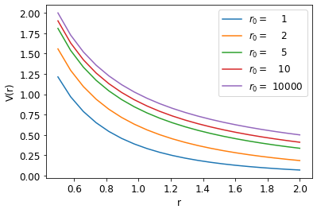

```python
V0 = 1.0
r0vals = np.array( [1.0, 2.0, 5.0, 10.0, 10000.] )
rplot = np.linspace(0.5,2,20)

for ir0, r0 in enumerate(r0vals):
    yuk_pot = scattering.yukawa( V0, r0 )
    vvals = [ yuk_pot(r) for r in rplot ]
    plt.plot(rplot,vvals, label=r"$r_0= $ %4.0f" %(r0) )
plt.legend()
plt.xlabel("r")
plt.ylabel("V(r)")
plt.show()
```

### Simulate the trajectory for several values of $r_0$.

We also keep track of $\theta(b)$ in a separate array for convenience.

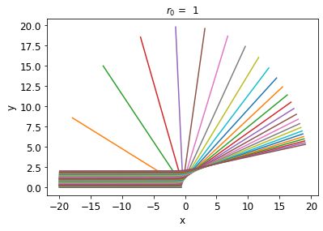

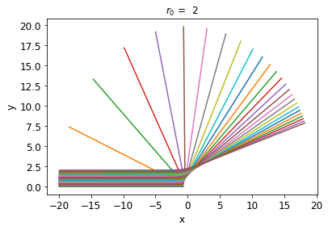

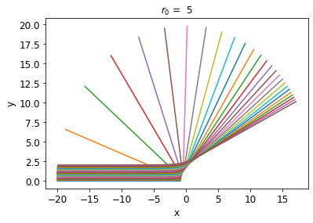

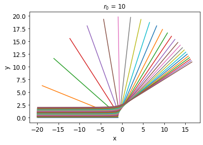

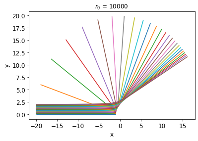

```python
E = 1.0
V0 = 1.0

b_min = 0.0
b_max = 2.0
n_b = 25
bvals = np.linspace(b_min,b_max,n_b+1)


r0_theta_b = np.zeros( shape=(len(r0vals),n_b+1) )


for ir0,r0val in enumerate(r0vals):
    yukawa = scattering.yukawa( V0,r0val )
    fig = plt.figure(ir0+1)
    for ib,b in enumerate(bvals):
        xs = scattering.CrossSection_yukawa( yukawa, E, b, 20.0, 10000 )
        deflection = xs.calculate_trajectory()
        traj = np.asarray( xs.get_trajectory() )
        r0_theta_b[ir0,ib] = traj[-1,1]
        # Reduce the steps for plotting
        x,y = traj[::100,0] * np.cos( traj[::100,1] ), traj[::100,0] * np.sin(traj[::100,1])
        plt.plot(x,y, label="%3.1f"%(b))
        plt.title(r"$r_0$ = %2.0f"%(r0val))
        plt.xlabel("x")
        plt.ylabel("y")
        #plt.legend()

plt.show()
```

### Plot $\theta(b)$

Here, we are also looking at the analytical solution for Rutherford scattering. This needs some derivation.

We know that the impact parameter as a function of angle for the Coulomb case is

$$ b = \frac{kq_1q_2}{2E} \cot(\theta/2) $$

Rearranging:

$$ b = \frac{V_0}{2E} \frac{1}{\tan(\theta/2)} $$

Inverting this we get

$$ \theta = 2 \tan^{-1}\left(\frac{V_0}{2Eb}\right) $$

The simulation does a good job at low impact parameters, but it starts to diverge for larger impact parameters.

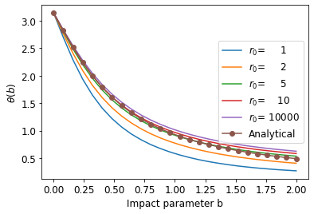

```python
theta_b_ana = 2*np.arctan2(V0,(2*E*bvals))
for ir0,r0val in enumerate(r0vals):
    plt.plot( bvals, r0_theta_b[ir0,:],label=r"$r_0$=%6.0f"%(r0val))
plt.plot( bvals, theta_b_ana , label="Analytical", marker='o')
plt.xlabel("Impact parameter b")
plt.ylabel(r"$\theta(b)$")
plt.legend(loc="right")
```

### Plot $d\theta / db$

As in Problem 2, I will use a binned five-point method.

The analytical solution in this case is

```python
def derivative_fivepoint_binned( a, h) :
    dfdx = (a[:,0:-3] - 8*a[:,1:-2] + 8 * a[:,2:-1] - a[:,3:]) / (12*h)
    return dfdx
```

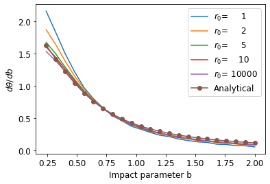

```python
db = (b_max - b_min) / n_b
dtheta_db_yuk = derivative_fivepoint_binned(r0_theta_b[:,:], db)
dtheta_db_ana = 2 / (4*bvals[3:]**2 + 1)
for ir0,r0val in enumerate(r0vals):
    plt.plot( bvals[3:], np.abs(dtheta_db_yuk[ir0,:]),label=r"$r_0$=%6.0f"%(r0val))
plt.plot( bvals[3:], dtheta_db_ana , label="Analytical", marker='o')
plt.xlabel("Impact parameter b")
plt.ylabel(r"$d\theta/db$")
plt.legend()
```

The analytic solution is doing a pretty good job here!

### Plot $d\sigma / d\Omega$

Finally, the analytic solution here is putting the pieces above together:

```python
dsigma_domega_ana = bvals[3:] / np.sin(theta_b_ana[3:]) / dtheta_db_ana
```

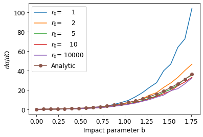

```python
for ir0,r0val in enumerate(r0vals):
    dsigma_domega_yuk = bvals[:-3] / np.sin(r0_theta_b[ir0,:-3])/ dtheta_db_yuk[ir0,:]
    plt.plot( bvals[:-3], np.abs(dsigma_domega_yuk), label=r"$r_0$=%6.0f"%(r0val) )
plt.plot(bvals[:-3], dsigma_domega_ana, label="Analytic", marker='o')
plt.xlabel("Impact parameter b")
plt.ylabel(r"$d\sigma / d\Omega$")

plt.legend()
```

Again, we see agreement at the lower values of impact parameter, with some small errors at larger $b$.